# Campaign Contributions and Bureaucratic Oversight

```r
# Full model with interaction:
mPro_Fullx <- glm(ProBusiness_Letters ~ PAC_contributions*party, data = letters_money %>% filter(!party %in% c("NA","(I)", "Independent"))%>% mutate(PAC_contributions = PAC_contributions/1000000), family = "poisson" )

tidy(mPro_Fullx)
```

```
## # A tibble: 4 x 5
##   term                       estimate std.error statistic   p.value
##   <chr>                         <dbl>     <dbl>     <dbl>     <dbl>
## 1 (Intercept)                 -1.16      0.0493  -23.5    7.68e-122
## 2 PAC_contributions            0.0357    1.25      0.0286 9.77e-  1
## 3 party(R)                     0.0372    0.0714    0.520  6.03e-  1
## 4 PAC_contributions:party(R)   0.904     1.45      0.624  5.33e-  1
```

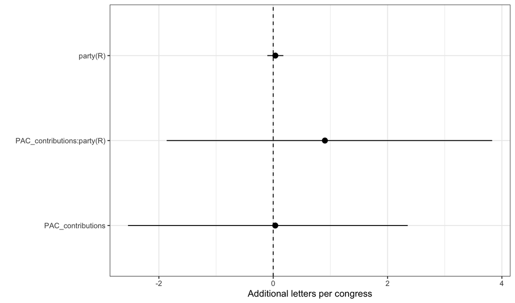

```r
mplot(mPro_Fullx)+
  labs(x="", y="Additional letters per congress")
```

```r
mAnti_Full <- glm(AntiBusiness_Letters ~ PAC_contributions + party, data = Antiletters_money %>% filter(!party %in% c("NA","(I)", "Independent"))%>% mutate(PAC_contributions = PAC_contributions/1000000), family = "poisson" )

tidy(mAnti_Full)
```

```
## # A tibble: 3 x 5
##   term              estimate std.error statistic  p.value
##   <chr>                <dbl>     <dbl>     <dbl>    <dbl>
## 1 (Intercept)         -0.468    0.0326    -14.3  1.14e-46
## 2 PAC_contributions   -2.20     0.650      -3.39 6.97e- 4
## 3 party(R)            -0.277    0.0482     -5.74 9.29e- 9
```

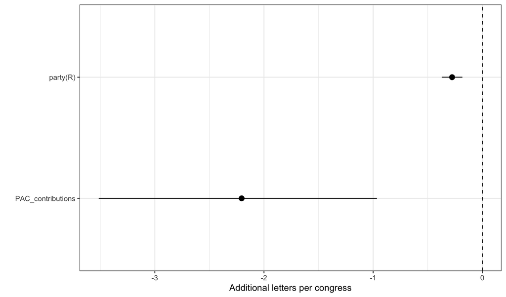

```r
mplot(mAnti_Full)+
  labs(x="", y="Additional letters per congress")
```

```r
# full model with interaction
mAnti_Fullx <- glm(AntiBusiness_Letters ~ PAC_contributions*party, data = Antiletters_money %>% filter(!party %in% c("NA","(I)", "Independent"))%>% mutate(PAC_contributions = PAC_contributions/1000000), family = "poisson" )
tidy(mAnti_Fullx)
```

```
## # A tibble: 4 x 5
##   term                       estimate std.error statistic  p.value
##   <chr>                         <dbl>     <dbl>     <dbl>    <dbl>
## 1 (Intercept)                  -0.462    0.0361   -12.8   1.56e-37
## 2 PAC_contributions            -2.51     1.05      -2.38  1.72e- 2
## 3 party(R)                     -0.289    0.0588    -4.92  8.76e- 7
## 4 PAC_contributions:party(R)    0.501    1.34       0.374 7.08e- 1
```

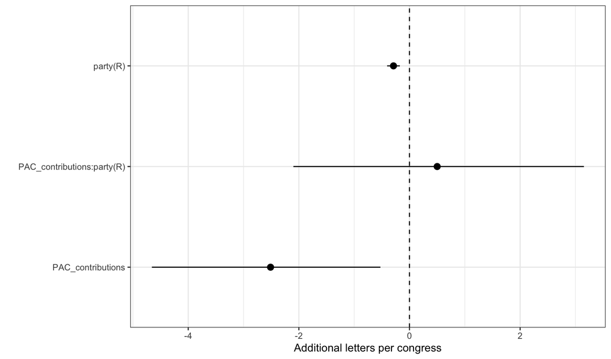

```r
mplot(mAnti_Fullx)+
  labs(x="", y="Additional letters per congress")
```

```r
# FULL MODEL WITH NON- CONSTITUENT
# FIXME
#mNonConstituent_Fullx <- glm(NonConstituent_Letters ~ PAC_contributions*party, data = NonConstituent_letters_money %>% filter(!party %in% c("NA","(I)", "Independent"))%>% mutate(PAC_contributions = PAC_contributions/1000000), family = "poisson" )
#tidy(mNonConstituent_Fullx)
#mplot(mNonConstituent_Fullx)+labs(x="", y="Additional non-constituent letters per congress")
```

#### Average Pro-Business letters per cycle ~ total Energy Sector PAC contributions 1990-2014

```r
mProTotal <- glm(ProBusiness_Letters_Per_Cycle ~ PAC_contributions, data = letters_money_total%>% mutate(PAC_contributions = PAC_contributions/1000000), family = "poisson")

tidy(mProTotal)
```

```
## # A tibble: 2 x 5
##   term              estimate std.error statistic  p.value
##   <chr>                <dbl>     <dbl>     <dbl>    <dbl>
## 1 (Intercept)          -1.80    0.0911    -19.7  1.38e-86
## 2 PAC_contributions     1.11    0.206       5.39 7.01e- 8
```

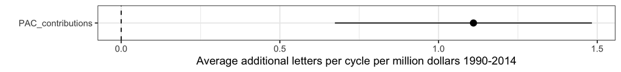

```r
mplot(mProTotal)+
  labs(x="", y="Average additional letters per cycle per million dollars 1990-2014")
```

#### Anti-Business Letters per cycle ~ Energy Sector PAC contributions per cycle 1998-2014

```r
Antiletters_money %<>%
  #drop_na(AntiBusiness_Letters, PAC_contributions) %>%
  mutate(Log_PAC_contributions = log(PAC_contributions+1))

mAnti <- glm(AntiBusiness_Letters ~ PAC_contributions, data = Antiletters_money %>% mutate(PAC_contributions = PAC_contributions/1000000), family = poisson)
tidy(mAnti)
```

```
## # A tibble: 2 x 5
##   term              estimate std.error statistic   p.value
##   <chr>                <dbl>     <dbl>     <dbl>     <dbl>
## 1 (Intercept)         -0.905    0.0282    -32.1  1.33e-226
## 2 PAC_contributions   -1.28     0.625      -2.05 4.07e-  2
```

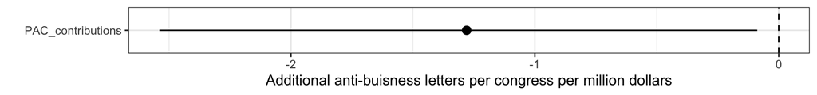

```r
mAnti %>% mplot()+
  labs(x="", y="Additional anti-buisness letters per congress per million dollars")
```

```r
mAntiLog <- glm(AntiBusiness_Letters ~ Log_PAC_contributions, data = Antiletters_money, family = poisson  )
tidy(mAntiLog)
```

```
## # A tibble: 2 x 5
##   term                  estimate std.error statistic  p.value
##   <chr>                    <dbl>     <dbl>     <dbl>    <dbl>
## 1 (Intercept)            -0.737    0.0554     -13.3  2.56e-40
## 2 Log_PAC_contributions  -0.0245   0.00621     -3.94 8.30e- 5
```

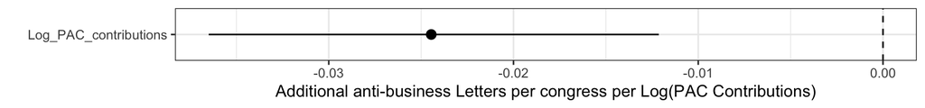

```r
mAntiLog %>% mplot()+
  labs(x="", y="Additional anti-business Letters per congress per Log(PAC Contributions)")
```

#### By party:

```r
mAntiParty <- glm(AntiBusiness_Letters ~ party, data = Antiletters_money %>% filter(!party %in% c("NA","(I)", "Independent")), family = "poisson" )

tidy(mAntiParty)
```

```
## # A tibble: 2 x 5
##   term        estimate std.error statistic  p.value
##   <chr>          <dbl>     <dbl>     <dbl>    <dbl>
## 1 (Intercept)   -0.500    0.0299    -16.7  7.60e-63
## 2 party(R)      -0.166    0.0446     -3.73 1.90e- 4
```

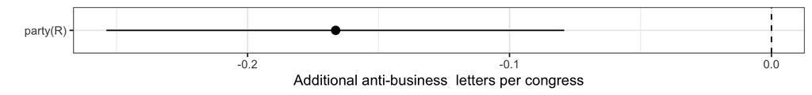

```r
mplot(mAntiParty) +
  labs(x="", y="Additional anti-business  letters per congress")
```

Democrats send an additional 0.2 Anti-Business letters per Congress, on average.

```r
#PAC*party interaction:
mAnti_pacXparty <-glm(AntiBusiness_Letters ~ PAC_contributions*party, data = Antiletters_money %>% filter(party !="NA")%>% mutate(PAC_contributions = PAC_contributions/1000000), family = "poisson" )
tidy(mAnti_pacXparty)
```

```
## # A tibble: 4 x 5
##   term                       estimate std.error statistic  p.value
##   <chr>                         <dbl>     <dbl>     <dbl>    <dbl>
## 1 (Intercept)                  -0.462    0.0361   -12.8   1.56e-37
## 2 PAC_contributions            -2.51     1.05      -2.38  1.72e- 2
## 3 party(R)                     -0.289    0.0588    -4.92  8.76e- 7
## 4 PAC_contributions:party(R)    0.501    1.34       0.374 7.08e- 1
```

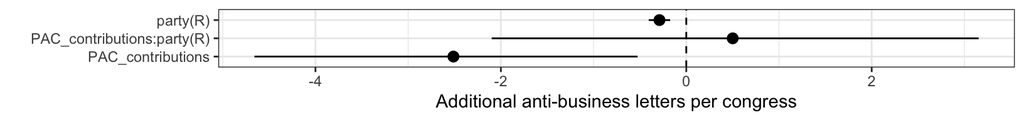

```r
mplot(mAnti_pacXparty)+
  labs(x="", y="Additional anti-business letters per congress")
```

#### Average Anti-Business letters per cycle ~ total Energy Sector PAC contributions 1990-2014

```r
mAntiTotal <- glm(AntiBusiness_Letters_Per_Cycle ~ PAC_contributions, data = Antiletters_money_total%>% mutate(PAC_contributions = PAC_contributions/1000000), family = "poisson")

tidy(mAntiTotal)
```

```
## # A tibble: 2 x 5
##   term              estimate std.error statistic  p.value
##   <chr>                <dbl>     <dbl>     <dbl>    <dbl>
## 1 (Intercept)         -1.23     0.0747    -16.5  2.31e-61
## 2 PAC_contributions    0.660    0.209       3.16 1.58e- 3
```

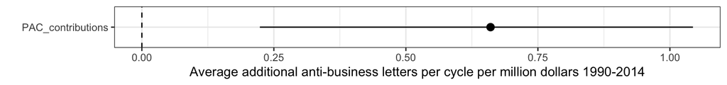

```r
mplot(mAntiTotal)+
  labs(x="", y="Average additional anti-business letters per cycle per million dollars 1990-2014")
```

# Combined models

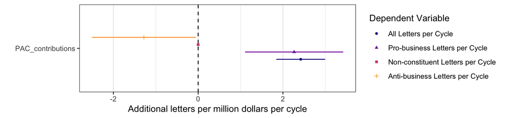

```r
library(dplyr)
dplot <- function(x){dwplot(x) +
    aes(shape = model) +
    geom_vline(xintercept = 0, linetype = 2) +
    scale_color_viridis_d(option = "C", end = .8) +
    labs(color = "Dependent Variable",
         shape = "Dependent Variable") +
  theme(panel.grid.major.y  = element_blank())
}

# Basic PAC money models
models <- full_join(
  tidy(mAll) %>% mutate(model = "All Letters per Cycle"),
  tidy(mPro) %>% mutate(model = "Pro-business Letters per Cycle") ) %>%
  full_join(tidy(mNonConstituent) %>% mutate(model = "Non-constituent Letters per Cycle")) %>%
  full_join(tidy(mAnti)  %>% mutate(model = "Anti-business Letters per Cycle"))

dplot(models)+
    labs(color = "Dependent Variable",
         shape = "Dependent Variable",
         x = "Additional letters per million dollars per cycle")
```

```r
library(stargazer)
library(dplyr)
write_lines(stargazer(mAll, mPro, mAnti, mNonConstituent, float=F),
  path = here("FERC/tables/All-mPro-mAnti-mNonConstituent.tex"))

table <- stargazer(mAll, mPro, mAnti, mNonConstituent,
                type = "html",
                notes = "FERC/tables/All-mPro-mAnti-mNonConstituent.tex")
```

```r
kable(table)
```

| x |
| --- |

|

|  | *Dependent variable:* |  |  |  |
| --- | --- | --- | --- | --- |
|  | All_Letters | ProBusiness_Letters | AntiBusiness_Letters | Non_Constituent_Letters |
|  | (1) | (2) | (3) | (4) |
| PAC_contributions | 2.420*** | 2.265*** | -1.280** | 0.00000*** |
|  | (0.294) | (0.591) | (0.625) | (0.00000) |
| Constant | -0.109*** | -1.472*** | -0.905*** | -0.109*** |
|  | (0.018) | (0.035) | (0.028) | (0.018) |
| Observations | 4,780 | 4,780 | 4,780 | 4,780 |
| Log Likelihood | -9,313.050 | -3,346.886 | -5,007.848 | -9,313.050 |
| Akaike Inf. Crit. | 18,630.100 | 6,697.773 | 10,019.690 | 18,630.100 |
| *Note:* | p<0.1; p<0.05; p<0.01 |  |  |  |
|  | FERC/tables/All-mPro-mAnti-mNonConstituent.tex |  |  |  |

### logged PAC money models

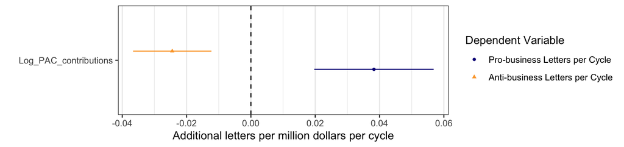

```r
## logged PAC money models
models <- tidy(mProLog) %>% mutate(model = "Pro-business Letters per Cycle") %>%
full_join(tidy(mAntiLog) %>% mutate(model = "Anti-business Letters per Cycle"))

dplot(models)+
    labs(x = "Additional letters per million dollars per cycle")
```

```r
write_lines(
  stargazer::stargazer(mProLog, mAntiLog,
                       float=F),
  path = here("FERC/tables/mProLog-mAntiLog.tex"))

table <- stargazer(mProLog, mAntiLog,
                type = "html",
                notes = "FERC/tables/mProLog-mAntiLog.tex")
```

```r
kable(table)
```

| x |
| --- |

|

|  | *Dependent variable:* |  |
| --- | --- | --- |
|  | ProBusiness_Letters | AntiBusiness_Letters |
|  | (1) | (2) |
| Log_PAC_contributions | 0.038*** | -0.024*** |
|  | (0.009) | (0.006) |
| Constant | -1.735*** | -0.737*** |
|  | (0.089) | (0.055) |
| Observations | 4,780 | 4,780 |
| Log Likelihood | -3,344.449 | -5,002.673 |
| Akaike Inf. Crit. | 6,692.897 | 10,009.340 |
| *Note:* | p<0.1; p<0.05; p<0.01 |  |
|  | FERC/tables/mProLog-mAntiLog.tex |  |

### PAC contributions over entire time period

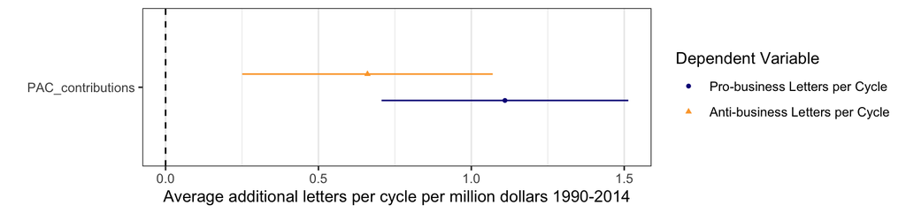

```r
## PAC contributions over entire time period
models <- tidy(mProTotal) %>%
  mutate(model = "Pro-business Letters per Cycle") %>%
  full_join(tidy(mAntiTotal) %>% mutate(model = "Anti-business Letters per Cycle"))

dplot(models) +
    labs(x = "Average additional letters per cycle per million dollars 1990-2014")
```

```r
write_lines(
  stargazer::stargazer(mProTotal, mAntiTotal, float=F),
  path = here("FERC/tables/mProTotal-mAntiTotal.tex"))

table <- stargazer(mProTotal, mAntiTotal,
                type = "html",
                notes = "FERC/tables/mProTotal-mAntiTotal.tex")
```

```r
kable(table)
```

| x |
| --- |

|

|  | *Dependent variable:* |  |
| --- | --- | --- |
|  | ProBusiness_Letters_Per_Cycle | AntiBusiness_Letters_Per_Cycle |
|  | (1) | (2) |
| PAC_contributions | 1.110*** | 0.660*** |
|  | (0.206) | (0.209) |
| Constant | -1.797*** | -1.234*** |
|  | (0.091) | (0.075) |
| Observations | 899 | 893 |
| Log Likelihood | -Inf.000 | -Inf.000 |
| Akaike Inf. Crit. | Inf.000 | Inf.000 |
| *Note:* | p<0.1; p<0.05; p<0.01 |  |
|  | FERC/tables/mProTotal-mAntiTotal.tex |  |

### Party

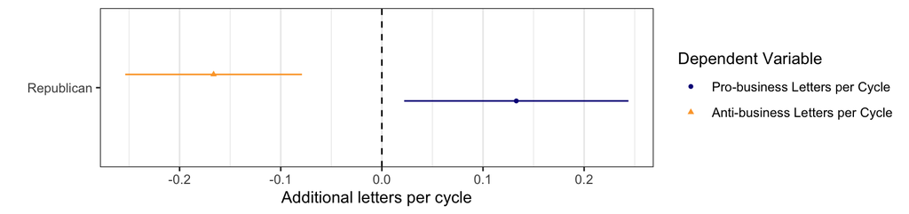

```r
## With party IV
models <- tidy(mProParty) %>%
  mutate(model = "Pro-business Letters per Cycle") %>%
  full_join(tidy(mAntiParty) %>%
              mutate(model = "Anti-business Letters per Cycle")) %>%
  mutate(term = str_replace(term, "party\\(R\\)", "Republican")) %>%
  filter(term != "party(I)")

dplot(models) +
    labs(x = "Additional letters per cycle")
```

```r
write_lines(
  stargazer::stargazer(mProParty, mAntiParty, float=F),
  path = here("FERC/tables/mProParty-mAntiParty.tex"))

table <- stargazer(mProParty, mAntiParty,
                type = "html",
                notes = "FERC/tables/mProParty-mAntiParty.tex")
```

```r
kable(table)
```

| x |
| --- |

|

|  | *Dependent variable:* |  |
| --- | --- | --- |
|  | ProBusiness_Letters | AntiBusiness_Letters |
|  | (1) | (2) |
| party(R) | 0.133** | -0.166*** |
|  | (0.057) | (0.045) |
| Constant | -1.136*** | -0.500*** |
|  | (0.041) | (0.030) |
| Observations | 3,645 | 3,624 |
| Log Likelihood | -3,157.349 | -5,016.875 |
| Akaike Inf. Crit. | 6,318.697 | 10,037.750 |
| *Note:* | p<0.1; p<0.05; p<0.01 |  |
|  | FERC/tables/mProParty-mAntiParty.tex |  |

### All univariate models

```r
# All models
write_lines(
  stargazer::stargazer(mAll, mPro, mAnti,mNonConstituent, mProLog, mAntiLog, mProParty, mProTotal, mAntiTotal, mAntiParty, float = F),
  path = here("FERC/tables/mUnivariate.tex"))

table <-stargazer(mAll, mPro, mAnti, mNonConstituent, mProLog, mAntiLog, mProParty, mProTotal, mAntiTotal, mAntiParty,
                type = "html",
                notes = "FERC/tables/mUnivariate.tex")
```

```r
kable(table)
```

| x |
| --- |

|

|  | *Dependent variable:* |  |  |  |  |  |  |  |  |  |
| --- | --- | --- | --- | --- | --- | --- | --- | --- | --- | --- |
|  | All_Letters | ProBusiness_Letters | AntiBusiness_Letters | Non_Constituent_Letters | ProBusiness_Letters | AntiBusiness_Letters | ProBusiness_Letters | ProBusiness_Letters_Per_Cycle | AntiBusiness_Letters_Per_Cycle | AntiBusiness_Letters |
|  | (1) | (2) | (3) | (4) | (5) | (6) | (7) | (8) | (9) | (10) |
| PAC_contributions | 2.420*** | 2.265*** | -1.280** | 0.00000*** |  |  |  | 1.110*** | 0.660*** |  |
|  | (0.294) | (0.591) | (0.625) | (0.00000) |  |  |  | (0.206) | (0.209) |  |
| Log_PAC_contributions |  |  |  |  | 0.038*** | -0.024*** |  |  |  |  |
|  |  |  |  |  | (0.009) | (0.006) |  |  |  |  |
| party(R) |  |  |  |  |  |  | 0.133** |  |  | -0.166*** |
|  |  |  |  |  |  |  | (0.057) |  |  | (0.045) |
| Constant | -0.109*** | -1.472*** | -0.905*** | -0.109*** | -1.735*** | -0.737*** | -1.136*** | -1.797*** | -1.234*** | -0.500*** |
|  | (0.018) | (0.035) | (0.028) | (0.018) | (0.089) | (0.055) | (0.041) | (0.091) | (0.075) | (0.030) |
| Observations | 4,780 | 4,780 | 4,780 | 4,780 | 4,780 | 4,780 | 3,645 | 899 | 893 | 3,624 |
| Log Likelihood | -9,313.050 | -3,346.886 | -5,007.848 | -9,313.050 | -3,344.449 | -5,002.673 | -3,157.349 | -Inf.000 | -Inf.000 | -5,016.875 |
| Akaike Inf. Crit. | 18,630.100 | 6,697.773 | 10,019.690 | 18,630.100 | 6,692.897 | 10,009.340 | 6,318.697 | Inf.000 | Inf.000 | 10,037.750 |
| *Note:* | p<0.1; p<0.05; p<0.01 |  |  |  |  |  |  |  |  |  |
|  | FERC/tables/mUnivariate.tex |  |  |  |  |  |  |  |  |  |

### All Full (multivariate) Models

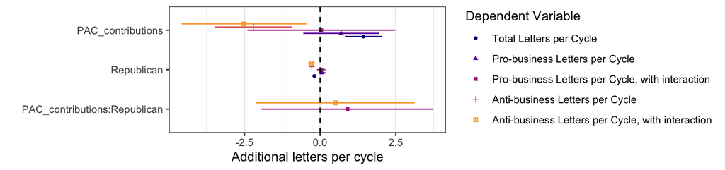

```r
## Full model
models <- tidy(mAll_Full) %>%
  mutate(model = "Total Letters per Cycle") %>%
  full_join(tidy(mPro_Full) %>%
              mutate(model = "Pro-business Letters per Cycle")) %>%
  full_join(tidy(mPro_Fullx) %>% mutate(model = "Pro-business Letters per Cycle, with interaction")) %>%
  full_join(tidy(mAnti_Full) %>%
              mutate(model = "Anti-business Letters per Cycle")) %>%
  full_join(tidy(mAnti_Fullx) %>% mutate(model = "Anti-business Letters per Cycle, with interaction")) %>%
  mutate(term = str_replace(term, "party\\(R\\)", "Republican"))

dplot(models) +
    labs(x = "Additional letters per cycle")
```

```r
write_lines(
  stargazer::stargazer(mAll_Full, mAll_Fullx, mPro_Full, mAnti_Full,mPro_Fullx, mAnti_Fullx, float=F),
  path = here("FERC/tables/mFull.tex"))

table <- stargazer(mPro_Full, mAnti_Full, mPro_Fullx, mAnti_Fullx,
                type = "html",
                notes = "FERC/tables/mFull.tex")
```

```r
kable(table)
```

| x |
| --- |

|

|  | *Dependent variable:* |  |  |  |
| --- | --- | --- | --- | --- |
|  | ProBusiness_Letters | AntiBusiness_Letters | ProBusiness_Letters | AntiBusiness_Letters |
|  | (1) | (2) | (3) | (4) |
| PAC_contributions | 0.694 | -2.205*** | 0.036 | -2.512** |
|  | (0.638) | (0.650) | (1.247) | (1.054) |
| party(R) | 0.062 | -0.277*** | 0.037 | -0.289*** |
|  | (0.060) | (0.048) | (0.071) | (0.059) |
| PAC_contributions:party(R) |  |  | 0.904 | 0.501 |
|  |  |  | (1.449) | (1.338) |
| Constant | -1.172*** | -0.468*** | -1.158*** | -0.462*** |
|  | (0.044) | (0.033) | (0.049) | (0.036) |
| Observations | 3,593 | 3,593 | 3,593 | 3,593 |
| Log Likelihood | -3,017.067 | -4,447.401 | -3,016.869 | -4,447.331 |
| Akaike Inf. Crit. | 6,040.134 | 8,900.802 | 6,041.738 | 8,902.661 |
| *Note:* | p<0.1; p<0.05; p<0.01 |  |  |  |
|  | FERC/tables/mFull.tex |  |  |  |

## PAC-level

### Before matching projects and companies to their parent companies:

```r
# letter count per pac ~ pac contributions (lots of 0$-0letter pairs )
# 1. id pacs per letter - spit letters matching several pacs
# 2. count up per member
# 3. add 0s for all other pac-member-cycle compinations
# merge in with contributions per pac per member

# First, clean up the contributions data a bit

# a helper function to concat unique strings
unique_string <- . %>%
  str_split(";") %>%
  # select unique ones
  unlist() %>%
  unique() %>%
  trimws() %>%
  # paste them back together to retrun a single value
  paste(collapse = ";") %>%
  str_remove_all("na;|;na$|NA;|;NA$")

# Just the PAC names and IDs from the contributions matrix (will merge in relevent contributions later)
PACs <- contrib_matrix %>%
  select(comid, UltOrg,Affiliate,PACShort) %>% distinct() %>%
  # make a full list of pac-affiliated orgs
  group_by(comid) %>%
  mutate(UltOrg2 = str_c(UltOrg,Affiliate,PACShort, sep = ";") %>%
           tolower() %>%
           # select unique ones
           unique_string())

# A function to get matching names
get_pac <- function(corp, PAC){
  ifelse(str_detect(tolower(PAC), tolower(corp)), PAC, NA)
}

# A function to get IDs where names match
get_pacID <- function(corp, PAC, PACid){
  ifelse(str_detect(tolower(PAC), tolower(corp)), PACid, NA)
}


# corp = "Exxon"

# A function to augment the PAC data with any matching company names
get_pacs <- function(corp){
PACs %>%
    mutate(pacs = get_pac(tolower(corp), UltOrg2),
           pacIDs = get_pacID(tolower(corp), UltOrg2, comid)) %>%
    ungroup() %>%
    select(pacs, pacIDs) %>%
    distinct() %>%
    summarise_all(unique_string) %>%
    mutate(company_short = corp)
}

# TESTING
# corp = "Exxon"
# get_pacs(corp)
# corp <- dcorps$company_short[1]
# get_pacs(corp)

crosswalk <- map_dfr(dcorps$company_short, get_pacs)

crosswalk %<>% distinct()

# use crosswalk to merge in contribution data
dpacs <- dcorps %>%
  full_join(crosswalk) %>%
  # letters per year per pac
  select(ID, position, company_short, position, pacs, pacIDs) %>%
  distinct() %>%
  mutate(pacIDs = str_split(pacIDs, ";")) %>%
  unnest(pacIDs) %>%
  distinct() %>%
  # merge in pac totals
  dplyr::rename(comid = pacIDs) %>%
  # merge in contribution data
  left_join(contrib_matrix) # %>% group_by(comid, position) %>% summarise(PAC_contributions)

dpacs %<>%
  ungroup() %>%
  filter(!is.na(ID), !is.na(comid)) %>%
  select(ID, icpsryear, cycle, name_state, position, company_short, pacs, comid, PAC_contributions) %>%
  distinct()
```

#### Pro-business letters linked to PAC contributions:

```r
dpacs %>%
  filter(position %in% c("ProBusiness", "ProProject")) %>%
  # select letters with an identified person
  drop_na(name_state, ID) %>%
  group_by(name_state, cycle, position, company_short, pacs, comid) %>%
  distinct()%>%  summarise(PAC_contributions = sum(PAC_contributions, na.rm = T),
                           # FIXME
                           # SHOULD NOT NEED UNIQUE HERE
            Letter_IDs = paste(unique(ID), collapse = ";")) %>%
  ungroup() %>%
  group_by(position)  %>%
  top_n(10, PAC_contributions) %>%
  knitr::kable()
```

[output not shown]

#### Anti-business letters linked to PAC contributions:

```r
dpacs %>%
  filter(position %in% c("AntiBusiness", "AntiProject")) %>%
  left_join(d %>% select(ID, Constituent) %>% distinct() ) %>%
  filter(Constituent == "No") %>%
  # select letters with an identified person
  drop_na(name_state, ID) %>%
  group_by(name_state, cycle, position, company_short, pacs, comid) %>%
  distinct()%>%  summarise(PAC_contributions = sum(PAC_contributions, na.rm = T),
                           # FIXME
                           # SHOULD NOT NEED UNIQUE HERE
            Letter_IDs = paste(unique(ID), collapse = ";")) %>%
  ungroup() %>%
  group_by(position)  %>%
  top_n(10, PAC_contributions) %>%
  knitr::kable()

#Before connecting companies to the PAC donations of their parent companies, we find `r sum(!is.na(dpacs$ID))` letters with a pack donation.
```

[output not shown]

[output not shown]

# About FERC

## Letters on behalf of projects in their districts

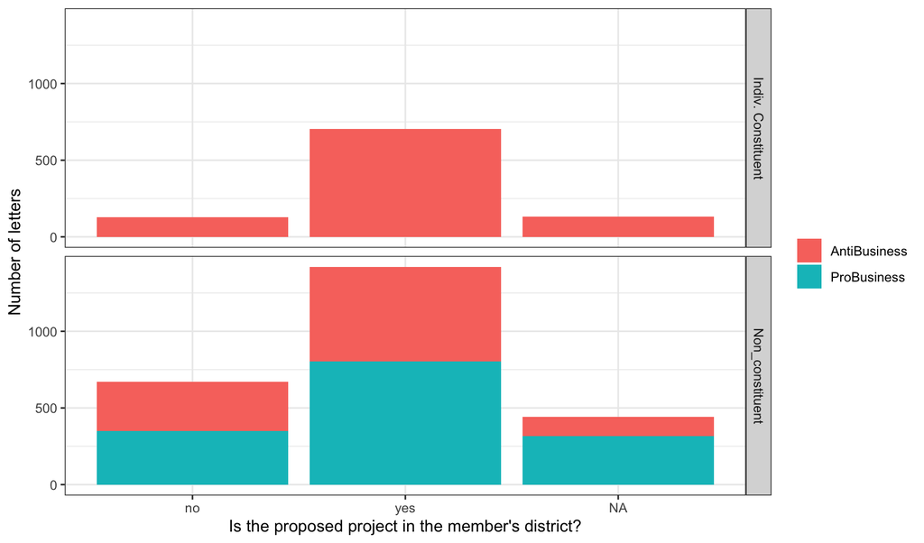

```r
d %>%
  mutate(Place_District = tolower(Place_District)) %>%
  # FIXME
  # dropping odd observations, will correct in DOE_FERC.R script
  filter(Place_District %in% c("yes", "no", NA)) %>%
  filter(letter_position %in% c("AntiBusiness", "ProBusiness")) %>%
  filter(Constituent != "Not coded") %>%
  count(Place_District, letter_position, Constituent) %>%
  ggplot() +
  aes(x = Place_District, y = n, fill = letter_position) +
  geom_col() +
  facet_grid(Constituent ~ .)+
  labs(x = "Is the proposed project in the member's district?",
       y = "Number of letters",
       fill = "")
```

## Comparing FERC to other agencies

# TO DO

## DONE

- add clean text from scraper to google sheet
- fix clean function to pull and combine new data
- link industry codes to CRP PAC committee classification:
1. Identify relevent industry codes
2. Get cycle-specific PAC classification for those industry codes
3. Subset dime to those PAC classification

## FERC Paper 2

- letters per company
- letters per company pac (before and after merging in partent companies)
- add company names from company scraper to google sheet
- template to match company names to donation (lobbyview, DIME)
- template match company names to industry codes (center for responsive politics)

## FERC Paper 1

- Fix Goode, who is being double counted as an R and I
- Add 2015-2018 DIME
- Fix DIME ICPSRs and check to make sure other members are not being dropped
- Identify companies that did not match a PAC and see if they match a parent company

## FERC Paper 2

- letters per company
- letters per company pac (before and after merging in partent companies)
- add company names from company scraper to google sheet
- template to match company names to donation (lobbyview, DIME)
- template match company names to industry codes (center for responsive politics)